# Bilgi Yönetim Sistemleri - Bitirme Projesi Rapor : Simge Buse Kaplan-210401011, Elif Avcı-200401073, Tesnim Strazimiri- 200401115, Sevim Kendir-190401075

2024-05-24

## Q1: İş probleminin tanımı

**Rame Games**, oyuncuların oyun alışkanlıklarını inceleyerek onlara daha eğlenceli ve bağımlılık yaratacak oyunlar sunmayı hedefleyen bir oyun şirketidir. Oyun geliştirme sürecinin başında oyuncuların oyunlardan beklentilerini, genel beğenilerini ve tercihlerini değerlendirmek adına 2024 verileri değerlendirilmek üzere seçilmiştir. Ancak kullanılacak olan SuiteCRM platformunda mapping işlemi esnasında yaşanan bir takım uyumsuzluklar ve 2024 yılının yalnızca dört aylık veri içeriyor olmasından kaynaklı olarak 2023 yılının 12 aylık verileri tercih edilmiştir. SuiteCRM, RESTful API aracılığıyla entegrasyonlar yapılmasına olanak tanır. API, SuiteCRM verilerine erişim ve veri manipülasyonu için kullanılabilir. SuiteCRM, müsteri ilişkileri yönetimi ve açık kaynaklı proje alanlarını bir araya getiren bir platformdur. Platform, Docker ile kurulabilme, hızlı bir şekilde geliştirme ve test ortamları oluşturmaya olanak verir. Docker, SuiteCRM’i hızlı bir şekilde dağıtıp kullanımı sağlayacak esnek bir altyapı sunar.

## Q2: İş Problemini Çözmede Kullanılacak Data Seti

Veriyi kaggle platformundan bulduk.

**Veri Seti linki =>** https://www.kaggle.com/datasets/thedevastator/global-video-game-sales

Bu veri seti, 100.000 kopyadan fazla satışı olan video oyunlarının bir listesini içerir. Veri seti, vgchartz.com’dan kazınarak oluşturulmuştur.Hangi platformların global satışları yönlendirdiğini, farklı bölgelerde en başarılı türlerin neler olduğunu ve bu faktörlerin zaman içinde nasıl değiştiğini gözlemler. Bu verileri analiz ederek oyun sektörünü daha iyi anlayabilir ve oyun geliştiricilerinin başarıya ulaşmasını sağlayan trendleri keşfetmeye yarar.

**Veri Setindeki Öznitelikler:**

- *Rank:* Oyunun global satışlara göre sıralaması.
- *Name:* Oyunun adı.
- *Platform:* Oyunun yayımlandığı platform.
- *Year:* Oyunun yayımlandığı yıl.
- *Genre:* Oyunun türü.
- *Publisher:* Oyunun yayımlayıcısı.
- *NA_Sales:* Oyunun Kuzey Amerika’daki satışları.
- *EU_Sales:* Oyunun Avrupa’daki satışları.
- *JP_Sales:* Oyunun Japonya’daki satışları.
- *Other_Sales:* Oyunun diğer bölgelerdeki satışları.
- *Global_Sales:* Oyunun dünya genelindeki toplam satışları.

Veri üzerinde öznitelik bilgilerinin hepsini küçük harf olarak düzenledik.

## Q3: Veri Seti Keşifsel Analizi

*Veri setinde önemli sütunlar ve bunların veri tipleri şunlardır:*

- *Rank:* ( char )
- *Name:* ( char )
- *Platform:* ( char )
- *Genre:* ( char )
- *Publisher:* ( char )
- *NA_Sales:* ( numeric )
- *EU_Sales:* ( numeric )
- *JP_Sales:* ( numeric )
- *Other_Sales:* ( numeric )
- *Global_Sales:* ( numeric )

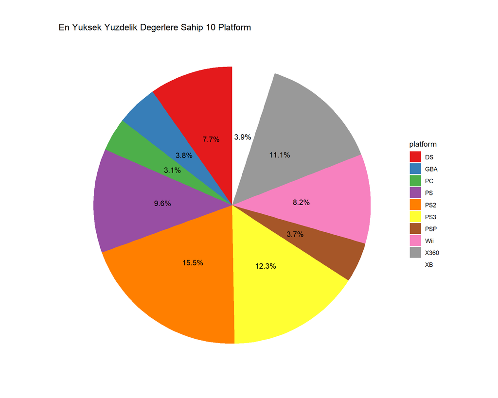

Yapılan analiz sonrasında oluşturulan dairesel grafikte en yüksek değerlere sahip 10 platformun yüzdelik değerleri yer almaktadır. Grafikte PS2’nin %15.5’lik yüzdeyle tüm platformlar arasında en yüksek değere sahip olduğu gözlemlenmektedir. PS3 ve X360 onu takip eden diğer iki en yüksek platformlar arasında, geriye kalan platformlar ise %10’nun altında değerlere sahiptir. Grafikte %3.1’lik değere sahip PC ise en düşük değere sahip platform olduğu görülmektedir.

[figure not shown]

SATIŞ DEĞERLERİNİN ORTALAMASI, MEDYANI VE MODU

|  | mean | median | mode |
| --- | --- | --- | --- |
| na_sales | 0.8675132 | 0.52 | 0.00 |
| eu_sales | 0.5082969 | 0.28 | 0.00 |
| jp_sales | 0.2249259 | 0.00 | 0.00 |
| other_sales | 0.1655237 | 0.08 | 0.04 |
| global_sales | 1.7663075 | 1.04 | 0.51 |

Bu tablo, farklı bölgelerdeki satış değerlerinin istatistiksel özetini sunmaktadır. İncelenen bölgeler Kuzey Amerika (NA), Avrupa (EU), Japonya (JP), diğer bölgeler (Other), ve küresel (Global) satışlardır. Tabloda her bölge için ortalama (mean), medyan (median) ve mod (mode) değerleri yer almaktadır.

**Mean(Ortalama):** Mean veri setindeki tüm veri noktalarının toplamının toplam veri noktasına bölümü ile edilen bir “ortalama” sayıdır.

**Median(Ortanca Değer):** Median sıralı bir veri setindeki orta değeri göstermektedir.

**Mode(Mod) :** Mode bir veri setinde en sık gözlemlenen değeri göstermektedir.

Bu tablodaki ortalama, medyan ve mod değerlerinin karşılaştırılması, farklı bölgelerdeki satış dağılımlarını daha iyi anlamamızı sağlar. Örneğin:

- **Kuzey Amerika (NA) Satışları:** NA satışlarının ortalaması ve medyanı, bu bölgedeki satışların nasıl dağıldığını anlamamıza yardımcı olur.
- **Avrupa (EU) Satışları:** EU satışlarının ortalama ve medyan değerleri, Avrupa pazarının Kuzey Amerika ile kıyaslandığında nasıl bir performans sergilediğini gösterir.
- **Japonya (JP) Satışları:** JP satışlarındaki ortalama ve medyan değerlerinin diğer bölgelerle karşılaştırılması, Japonya’nın pazardaki konumunu değerlendirmemize yardımcı olur.
- **Diğer Bölgeler ve Küresel Satışlar:** Diğer bölgeler ve küresel satışlar için hesaplanan değerler, bu bölgelerin toplam satışlar içindeki payını gösterir.

Genel olarak tablodaki satış verilerine göre pozitif çarpıklık söz konusudur. Ortalama medyandan büyük olduğu için, bu veri setinin sağa çarpık olduğunu söylenebilir. Aynı zamanda satışların çoğunluğu ortalama satış değerinin altında yoğunlaşmış, ancak bazı yüksek satış değerleri ortalamayı artırmıştır. Bu değerlendirmeler, satış stratejilerini belirlerken ve bölgesel pazarların önemini analiz ederken faydalı olacaktır.

VERİ SETİNDEKİ İLK 30 VERİ

| rank | name | platform | year | genre | publisher | na_sales | eu_sales | jp_sales | other_sales | global_sales |
| --- | --- | --- | --- | --- | --- | --- | --- | --- | --- | --- |
| 1 | Wii Sports | Wii | 2006 | Sports | Nintendo | 41.49 | 29.02 | 3.77 | 8.46 | 82.74 |
| 2 | Super Mario Bros. | NES | 1985 | Platform | Nintendo | 29.08 | 3.58 | 6.81 | 0.77 | 40.24 |
| 3 | Mario Kart Wii | Wii | 2008 | Racing | Nintendo | 15.85 | 12.88 | 3.79 | 3.31 | 35.82 |
| 4 | Wii Sports Resort | Wii | 2009 | Sports | Nintendo | 15.75 | 11.01 | 3.28 | 2.96 | 33.00 |
| 5 | Pokemon Red/Pokemon Blue | GB | 1996 | Role-Playing | Nintendo | 11.27 | 8.89 | 10.22 | 1.00 | 31.37 |
| 6 | Tetris | GB | 1989 | Puzzle | Nintendo | 23.20 | 2.26 | 4.22 | 0.58 | 30.26 |
| 7 | New Super Mario Bros. | DS | 2006 | Platform | Nintendo | 11.38 | 9.23 | 6.50 | 2.90 | 30.01 |
| 8 | Wii Play | Wii | 2006 | Misc | Nintendo | 14.03 | 9.20 | 2.93 | 2.85 | 29.02 |
| 9 | New Super Mario Bros. Wii | Wii | 2009 | Platform | Nintendo | 14.59 | 7.06 | 4.70 | 2.26 | 28.62 |
| 10 | Duck Hunt | NES | 1984 | Shooter | Nintendo | 26.93 | 0.63 | 0.28 | 0.47 | 28.31 |
| 11 | Nintendogs | DS | 2005 | Simulation | Nintendo | 9.07 | 11.00 | 1.93 | 2.75 | 24.76 |
| 12 | Mario Kart DS | DS | 2005 | Racing | Nintendo | 9.81 | 7.57 | 4.13 | 1.92 | 23.42 |
| 13 | Pokemon Gold/Pokemon Silver | GB | 1999 | Role-Playing | Nintendo | 9.00 | 6.18 | 7.20 | 0.71 | 23.10 |
| 14 | Wii Fit | Wii | 2007 | Sports | Nintendo | 8.94 | 8.03 | 3.60 | 2.15 | 22.72 |
| 15 | Wii Fit Plus | Wii | 2009 | Sports | Nintendo | 9.09 | 8.59 | 2.53 | 1.79 | 22.00 |
| 16 | Kinect Adventures! | X360 | 2010 | Misc | Microsoft Game Studios | 14.97 | 4.94 | 0.24 | 1.67 | 21.82 |
| 17 | Grand Theft Auto V | PS3 | 2013 | Action | Take-Two Interactive | 7.01 | 9.27 | 0.97 | 4.14 | 21.40 |
| 18 | Grand Theft Auto: San Andreas | PS2 | 2004 | Action | Take-Two Interactive | 9.43 | 0.40 | 0.41 | 10.57 | 20.81 |
| 19 | Super Mario World | SNES | 1990 | Platform | Nintendo | 12.78 | 3.75 | 3.54 | 0.55 | 20.61 |
| 20 | Brain Age: Train Your Brain in Minutes a Day | DS | 2005 | Misc | Nintendo | 4.75 | 9.26 | 4.16 | 2.05 | 20.22 |
| 21 | Pokemon Diamond/Pokemon Pearl | DS | 2006 | Role-Playing | Nintendo | 6.42 | 4.52 | 6.04 | 1.37 | 18.36 |
| 22 | Super Mario Land | GB | 1989 | Platform | Nintendo | 10.83 | 2.71 | 4.18 | 0.42 | 18.14 |
| 23 | Super Mario Bros. 3 | NES | 1988 | Platform | Nintendo | 9.54 | 3.44 | 3.84 | 0.46 | 17.28 |
| 24 | Grand Theft Auto V | X360 | 2013 | Action | Take-Two Interactive | 9.63 | 5.31 | 0.06 | 1.38 | 16.38 |
| 25 | Grand Theft Auto: Vice City | PS2 | 2002 | Action | Take-Two Interactive | 8.41 | 5.49 | 0.47 | 1.78 | 16.15 |
| 26 | Pokemon Ruby/Pokemon Sapphire | GBA | 2002 | Role-Playing | Nintendo | 6.06 | 3.90 | 5.38 | 0.50 | 15.85 |
| 27 | Pokemon Black/Pokemon White | DS | 2010 | Role-Playing | Nintendo | 5.57 | 3.28 | 5.65 | 0.82 | 15.32 |
| 28 | Brain Age 2: More Training in Minutes a Day | DS | 2005 | Puzzle | Nintendo | 3.44 | 5.36 | 5.32 | 1.18 | 15.30 |
| 29 | Gran Turismo 3: A-Spec | PS2 | 2001 | Racing | Sony Computer Entertainment | 6.85 | 5.09 | 1.87 | 1.16 | 14.98 |
| 30 | Call of Duty: Modern Warfare 3 | X360 | 2011 | Shooter | Activision | 9.03 | 4.28 | 0.13 | 1.32 | 14.76 |

## Q4: Veri Setinin BYS Platformuna İthali

Veri setimizi SuiteCRM platformuna entegre etmek için manuel import yöntemini kullanıldı ve belirli adımlar izlenildi. İlk olarak, SuiteCRM’e yönetici olarak giriş yapıldı ve “Admin” menüsünden “Module Builder” aracılığıyla “RameGames” adlı bir paket oluşturuldu.Bu paketin içine “Game1” adlı bir module oluşturuldu. Bu modülde, veri setinin sütun adlarını temsil eden alanları “Add Layouts” bölümünde “ListView” kısmında oluşturuldu ve mapping işlemi için gereken değişkenleri “Add Fields” kısmında eklendi. Sonrasında, CSV formatındaki veri seti bu modüle import edildi. Sütunlar otomatik olarak eşleştirildi ve veriler “Game1” sayfasında görünür hale getirildi. Bu adımlar sayesinde, veri seti SuiteCRM’e başarılı bir şekilde entegre edildi ve analizler için gerekli veriler platformda kullanılabilir hale getirildi.

## Q5: Yapılması Planlanan Veri Analizi

**Amaç**

Rame Games’in oyuncu etkileşimlerini optimize etmek, oyun performansını iyileştirmek, teknik sorunları hızlıca tespit etmek ve pazarlama stratejilerini etkili bir şekilde geliştirmek amacıyla mevcut veri seti üzerinde kritik analizler yapılması planlandı. Bu analizler, SuiteCRM’den çekilen veriler kullanılarak R Studio’da gerçekleştirilecek ve çeşitli grafikler ve istatistiksel yöntemler ile desteklenecektir.

*Analiz Planı*

- Veri Hazırlığı ve Temizleme
- Eksik verileri kontrol etmek ve gerekli temizleme işlemlerini yapmak.
- Satış verilerinin (na_sales, eu_sales, jp_sales, other_sales, global_sales) doğru biçimde olduğundan emin olmak.

*Temel İstatistiksel Analizler*

- Satış verilerinin (na_sales, eu_sales, jp_sales, other_sales, global_sales) ortalama, medyan, minimum ve maksimum değerlerini hesaplamak.
- Farklı platformlar, yıllar, türler bazında satış performansını analiz etmek.

*Grafiksel Analizler*

- Bar Grafikleri: Platform, tür bazında satış dağılımlarını göstermek.
- Dağılım Grafikleri: Farklı bölgelerdeki (NA, EU, JP, Other) satışların global satışlarla ilişkisini incelemek.

*Kategorik Analizler*

- Platform, tür bazında satış performansını analiz etmek.
- Farklı türlerin belirli platformlardaki başarı oranlarını incelemek.
- Segmentasyon ve Kümelenme Analizleri
- Satış verilerini kullanarak oyunları yüksek satışlı ve düşük satışlı olarak segmentlere ayırmak.
- Belirli segmentlerin (örneğin, yüksek satışlı oyunlar) platform ve tür bazında dağılımlarını incelemek.

## Q6 : Çalışan platformun gösterildiği sesli anlatımlı video

**Video Linki :**

*https://www.youtube.com/watch?v=pVM2XgaynU4*